# Regresión no lineal (nls y nls2)

Millán Trujillo, F. R.

Se utilizará la base de datos *Chwirut2* del paquete *NISTnls* del Instituto Nacional de Estándares y Tecnología (NIST por sus siglas en inglés). Lo datos corresponden a la respuesta ultrasónica como función de la distancia del metal empleado. La relación funcional se puede observar en el siguiente gráfico:

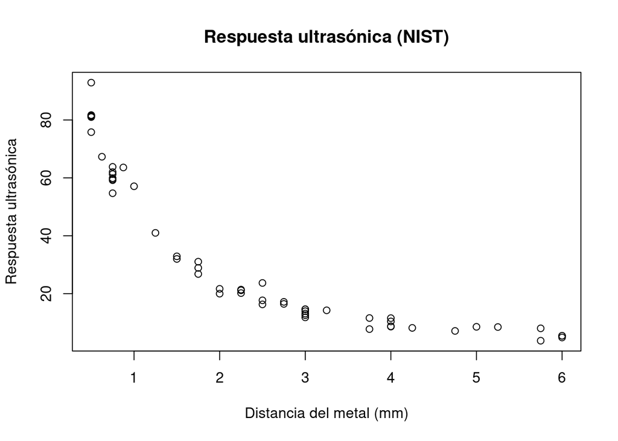

```r
library(NISTnls)
plot(y~x, data = Chwirut2,
     main = "Respuesta ultrasónica (NIST)",
     xlab = "Distancia del metal (mm)",
     ylab = "Respuesta ultrasónica")
```

Se desea modelar los datos con la función:

$$f(x,(\beta_1,\beta_2,\beta_3))=\frac{e^{-\beta_1x}}{\beta_2+\beta_3x}$$

Lo primero que vamos a hacer es definir la función en R:

```r
f <- function(x, beta1, beta2, beta3){
  exp(-beta1*x)/(beta2+beta3*x)
}
```

Ahora vamos a encontrar los valores iniciales de los predictores a fin de desarrollar el método iterativo de Gauss-Newton. Para ello crearemos una malla de valores iniciales y utilizaremos el algoritmo de *fuerza bruta* del paquete *nls2*. crearemos primero la malla (“grid”):

```r
malla <- expand.grid(list(beta1 = seq(0.1,1,by = 0.1),
                          beta2 = seq(0.01,0.05, by = 0.01),
                          beta3 = seq(0.1,1,by = 0.1)))
```

Ahora sí, una vez definida la función y un rango de potenciales valores de los coeficientes predictores, procederemos a forzar la estimación de los valores iniciales de tales coeficientes:

```r
library(nls2)
sub_model <- nls2(y ~ f(x,beta1,beta2,beta3),
                  data = Chwirut2,
                  start = malla,
                  algorithm = "brute-force")
sub_model
```

```
## Nonlinear regression model
##   model: y ~ f(x, beta1, beta2, beta3)
##    data: Chwirut2
## beta1 beta2 beta3
##  0.10  0.01  0.10
##  residual sum-of-squares: 60696
##
## Number of iterations to convergence: 500
## Achieved convergence tolerance: NA
```

Puede observarse que el algoritmo llega a la convergencia en 500 iteraciones, para obtener valores iniciales de los coeficientes iguales a $\beta_1=0.10$, $\beta_2=0.01$ y $\beta_3=0.10$. Encontrados estos valores iniciales, procederemos a minimizar la suma de cuadrados de los residuales (RSS por sus siglas en inglés):

```r
model <- nls(y~f(x,beta1,beta2,beta3),
             data = Chwirut2,
             start = list(beta1 = 0.10,
                          beta2 = 0.01,
                          beta3 = 0.10))
summary(model)
```

```
##
## Formula: y ~ f(x, beta1, beta2, beta3)
##
## Parameters:
##        Estimate Std. Error t value Pr(>|t|)
## beta1 0.1665779  0.0383034   4.349 6.56e-05 ***
## beta2 0.0051653  0.0006662   7.753 3.54e-10 ***
## beta3 0.0121500  0.0015304   7.939 1.81e-10 ***
## ---
## Signif. codes:  0 '***' 0.001 '**' 0.01 '*' 0.05 '.' 0.1 ' ' 1
##
## Residual standard error: 3.172 on 51 degrees of freedom
##
## Number of iterations to convergence: 6
## Achieved convergence tolerance: 4.386e-06
```

Observemos el gráfico de contornos de la RSS en función de los coeficientes ajustados:

```r
library(nlstools)
```

```r
contourmodel <- nlsContourRSS(model)
```

```
## 0%33%66%100%
##  RSS contour surface array returned
```

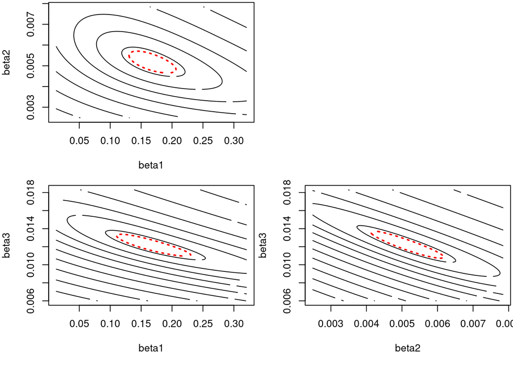

```r
plot(contourmodel, col = F, nlev = 10)
```

Obsérvese como se ha optimizado el valor de los predictores a fin de minimizar la suma de cuadrados de los residuales. Ahora procederemos a sobreponer la curva ajustada a los datos experimentales

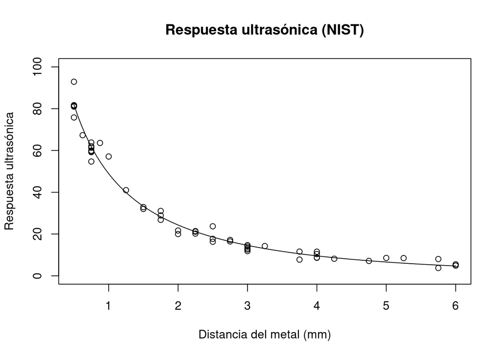

```r
plot(y~x, data = Chwirut2,
     main = "Respuesta ultrasónica (NIST)",
     xlab = "Distancia del metal (mm)",
     ylab = "Respuesta ultrasónica",
     ylim = c(0,100))
metaldistance <- with(Chwirut2, seq(min(x), max(x),
                                    length.out = 100))
lines(metaldistance, predict(model,
                             newdata =
                               data.frame(x = metaldistance)))
```